# Prediction of Biceps Curl Execution Quality

Magnus Hjelmfeldt

### Selecting prediction method

From the course lectures we learn that Random Forests are among the most accurate methods for prediction and that the downsides are mainly speed and the interpredabilty. Since the assignment does not put restrictions on either speed or interpretability of the model, Random Forests is choosen as prediction method.

### Exploring the data set

The raw data in the file pml-training.csv consists of 19622 observations and 160 variables. The very first step taken is to sub-section off the data into a training and test subset, with about 75% in the training and 25% in the test set. To select which variables to include in the building of the prediction model, the outcome variable, ‘classe’, is removed from the training data set. Aditionally it can be observed that the first seven columns of the data set (see appendix for the variable names) seems to be of more of an information nature, either about the subject or about the data collection.

After removing the seven information variables, a near zero value anaylysis is run to potentially exclude further variables. There are 53 variables with almost no variance (see variable names in appendix). After removing these variables there are 99 variables left. To check the completeness of data for the remaining columns, a plot of the ratio of missing values is created (with columns reordered for decending order of incompeteness).

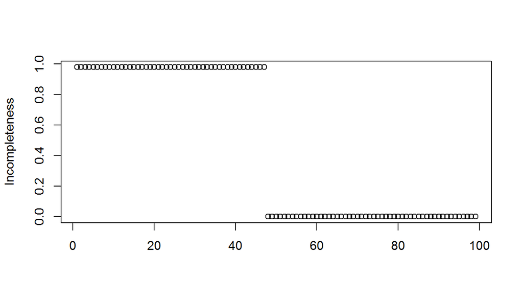

As seen in the above chart, about 45 variables are missing data for more than 95% of the observations. Since the portion of missing data for these variables is so large, rather than trying to impute data, these variables are removed (see variable names in appendix) and left is a dataset with 52 variables. For the remaining variables the data is fully complete, so no impution is needed. Since Random Forests is not sensitive to skewed variables, no further analysis or pre-processing of the variables are undertaken, and the remaining variables are selected to be included in the model. The selected variables are:

```
##  [1] "roll_belt"            "pitch_belt"           "yaw_belt"
##  [4] "total_accel_belt"     "gyros_belt_x"         "gyros_belt_y"
##  [7] "gyros_belt_z"         "accel_belt_x"         "accel_belt_y"
## [10] "accel_belt_z"         "magnet_belt_x"        "magnet_belt_y"
## [13] "magnet_belt_z"        "roll_arm"             "pitch_arm"
## [16] "yaw_arm"              "total_accel_arm"      "gyros_arm_x"
## [19] "gyros_arm_y"          "gyros_arm_z"          "accel_arm_x"
## [22] "accel_arm_y"          "accel_arm_z"          "magnet_arm_x"
## [25] "magnet_arm_y"         "magnet_arm_z"         "roll_dumbbell"
## [28] "pitch_dumbbell"       "yaw_dumbbell"         "total_accel_dumbbell"
## [31] "gyros_dumbbell_x"     "gyros_dumbbell_y"     "gyros_dumbbell_z"
## [34] "accel_dumbbell_x"     "accel_dumbbell_y"     "accel_dumbbell_z"
## [37] "magnet_dumbbell_x"    "magnet_dumbbell_y"    "magnet_dumbbell_z"
## [40] "roll_forearm"         "pitch_forearm"        "yaw_forearm"
## [43] "total_accel_forearm"  "gyros_forearm_x"      "gyros_forearm_y"
## [46] "gyros_forearm_z"      "accel_forearm_x"      "accel_forearm_y"
## [49] "accel_forearm_z"      "magnet_forearm_x"     "magnet_forearm_y"
## [52] "magnet_forearm_z"
```

### Performance tuning of Random Forests

Following the advice in the post [Improving Performance of Random Forest in caret::train()](https://github.com/lgreski/datasciencectacontent/blob/master/markdown/pml-randomForestPerformance.md) an adjustment to the standard train function in caret is used for training the model, where the resampling method is changed from the standard bootstrap, to a 10-fold cross validation.

### Resulting model

Below is the outcome of the summary of the trained model and its confusion matrix.

```
##
## Call:
##  randomForest(x = x, y = y, mtry = param$mtry)
##                Type of random forest: classification
##                      Number of trees: 500
## No. of variables tried at each split: 2
##
##         OOB estimate of  error rate: 0.62%
## Confusion matrix:
##      A    B    C    D    E  class.error
## A 4182    3    0    0    0 0.0007168459
## B   19 2824    5    0    0 0.0084269663
## C    0   17 2549    1    0 0.0070120764
## D    0    0   36 2374    2 0.0157545605
## E    0    0    1    7 2698 0.0029563932
```

### Cross Validated Out of Sample Error

The cross validated out of sample error rate is the out-of-bag (OOB) estimate of error rate, calculated by the train function in the caret package, i.e: 0.62% as seen in the summary above.

(The out of sample error rate can also be evaluated on the test sub set from the training set, calculated as 1-Accuracy, which yields: 0.61%.)

### Performance on test data

The above model fit, which was created with seed set to 780124, rendered a score of 20/20 on the test data quiz (i.e. on the data in pml-testing.csv).

## Appendix

Below are the names of the variables that were excluded at different stages in the data exploration.

### Information columns (one through seven)

```
## [1] "X"                    "user_name"            "raw_timestamp_part_1"
## [4] "raw_timestamp_part_2" "cvtd_timestamp"       "new_window"
## [7] "num_window"
```

### Near Zero Variance Variables

```
##  [1] "kurtosis_roll_belt"      "kurtosis_picth_belt"
##  [3] "kurtosis_yaw_belt"       "skewness_roll_belt"
##  [5] "skewness_roll_belt.1"    "skewness_yaw_belt"
##  [7] "max_yaw_belt"            "min_yaw_belt"
##  [9] "amplitude_yaw_belt"      "avg_roll_arm"
## [11] "stddev_roll_arm"         "var_roll_arm"
## [13] "avg_pitch_arm"           "stddev_pitch_arm"
## [15] "var_pitch_arm"           "avg_yaw_arm"
## [17] "stddev_yaw_arm"          "var_yaw_arm"
## [19] "kurtosis_roll_arm"       "kurtosis_picth_arm"
## [21] "kurtosis_yaw_arm"        "skewness_roll_arm"
## [23] "skewness_pitch_arm"      "skewness_yaw_arm"
## [25] "kurtosis_roll_dumbbell"  "kurtosis_picth_dumbbell"
## [27] "kurtosis_yaw_dumbbell"   "skewness_roll_dumbbell"
## [29] "skewness_pitch_dumbbell" "skewness_yaw_dumbbell"
## [31] "max_yaw_dumbbell"        "min_yaw_dumbbell"
## [33] "amplitude_yaw_dumbbell"  "kurtosis_roll_forearm"
## [35] "kurtosis_picth_forearm"  "kurtosis_yaw_forearm"
## [37] "skewness_roll_forearm"   "skewness_pitch_forearm"
## [39] "skewness_yaw_forearm"    "max_roll_forearm"
## [41] "max_yaw_forearm"         "min_roll_forearm"
## [43] "min_yaw_forearm"         "amplitude_yaw_forearm"
## [45] "avg_roll_forearm"        "stddev_roll_forearm"
## [47] "var_roll_forearm"        "avg_pitch_forearm"
## [49] "stddev_pitch_forearm"    "var_pitch_forearm"
## [51] "avg_yaw_forearm"         "stddev_yaw_forearm"
## [53] "var_yaw_forearm"
```

### Variables with high ratio of missing values

```
##  [1] "max_roll_belt"            "max_picth_belt"
##  [3] "min_roll_belt"            "min_pitch_belt"
##  [5] "amplitude_roll_belt"      "amplitude_pitch_belt"
##  [7] "var_total_accel_belt"     "avg_roll_belt"
##  [9] "stddev_roll_belt"         "var_roll_belt"
## [11] "avg_pitch_belt"           "stddev_pitch_belt"
## [13] "var_pitch_belt"           "avg_yaw_belt"
## [15] "stddev_yaw_belt"          "var_yaw_belt"
## [17] "var_accel_arm"            "max_roll_arm"
## [19] "max_picth_arm"            "max_yaw_arm"
## [21] "min_roll_arm"             "min_pitch_arm"
## [23] "min_yaw_arm"              "amplitude_roll_arm"
## [25] "amplitude_pitch_arm"      "amplitude_yaw_arm"
## [27] "max_roll_dumbbell"        "max_picth_dumbbell"
## [29] "min_roll_dumbbell"        "min_pitch_dumbbell"
## [31] "amplitude_roll_dumbbell"  "amplitude_pitch_dumbbell"
## [33] "var_accel_dumbbell"       "avg_roll_dumbbell"
## [35] "stddev_roll_dumbbell"     "var_roll_dumbbell"
## [37] "avg_pitch_dumbbell"       "stddev_pitch_dumbbell"
## [39] "var_pitch_dumbbell"       "avg_yaw_dumbbell"
## [41] "stddev_yaw_dumbbell"      "var_yaw_dumbbell"
## [43] "max_picth_forearm"        "min_pitch_forearm"
## [45] "amplitude_roll_forearm"   "amplitude_pitch_forearm"
## [47] "var_accel_forearm"
```